# TXT1_Chapter9_Assignment

# TXT1 Chapter 9 Assignment

# The purpose of this assignment is to implement and evaluate linear models using the dist_ssp_amfar_ch9 dataset. We create two linear models, with the second including the metro variable, to determine which variable can be used as a predictor for the distance variable. Through the interpretation of test statistics and comparing the two models, we can determine which variable is a statistically significant predictor.

# 04/17/2025

# Data: dist_ssp_amfar_ch9.csv in the assignment file

```r
#load the libraries
library(ggplot2)
library(lmtest)
```

## Question 1

```r
# load the dataset to variable ssp.data

ssp.data <- read.csv("dist_ssp_amfar_ch9.csv")
```

## Question 2

```r
# create model using lm() with cube root of outcome variable dist_SSP and opiod_RxRate as the predictor variable

dist.by.rx <- lm(I(dist_SSP^(1/3)) ~ opioid_RxRate, data=ssp.data)
```

## Question 3

```r
# Check the model assumptions

# Step 1: Independent Observations
str(ssp.data)
```

```
'data.frame':   500 obs. of  7 variables:
 $ county           : chr  "wabasha county" "johnson county" "iron county" "kosciusko county" ...
 $ STATEABBREVIATION: chr  "MN" "GA" "MO" "IN" ...
 $ dist_SSP         : num  47.4 125 77.2 42.1 49.2 ...
 $ HIVprevalence    : num  49.7 283.1 103.4 52.1 77.9 ...
 $ opioid_RxRate    : num  8.3 3 130.6 64.2 78.7 ...
 $ pctunins         : num  5.1 18.5 15.9 12.4 18.6 14.8 11.2 6.8 15.7 8.4 ...
 $ metro            : chr  "metro" "non-metro" "non-metro" "non-metro" ...
```

```r
# Step 2: Continuous Outcome
is.numeric(ssp.data$dist_SSP)
```

```
[1] TRUE
```

[figure not shown]

```r
# Step 3: Linearity
ggplot(ssp.data, aes(x = opioid_RxRate, y = I(dist_SSP^(1/3)))) +
  geom_point() +
  geom_smooth(method = "lm") +
  theme_bw() +
  labs(
    x = "Prescriptions per 100 people",
    y = "Cube root of dist to SSP"
  )
```

```r
# Step 4: Constant variance
bptest(dist.by.rx)
```

```
    studentized Breusch-Pagan test

data:  dist.by.rx
BP = 14.046, df = 1, p-value = 0.0001784
```

```r
# Step 5: Independence of residuals
dwtest(dist.by.rx)
```

```
    Durbin-Watson test

data:  dist.by.rx
DW = 2.0081, p-value = 0.5356
alternative hypothesis: true autocorrelation is greater than 0
```

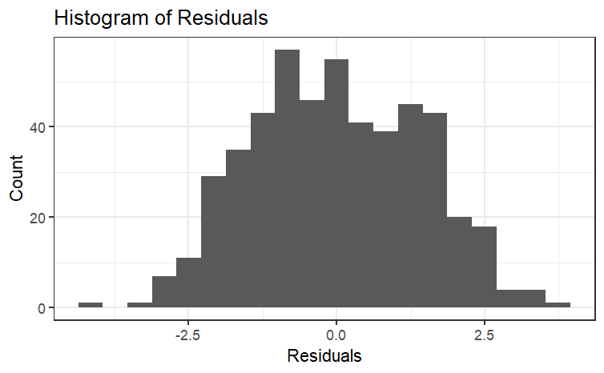

```r
# Step 6: Normality of residuals
residuals <- data.frame(res = residuals(dist.by.rx))

ggplot(residuals, aes(x = res)) +
  geom_histogram(bins = 20) +
  theme_bw() +
  labs(
    x = "Residuals",
    y = "Count",
    title = "Histogram of Residuals"
  )
```

## Question 4:

```r
# interpret the model results using summary()
summary(dist.by.rx)
```

```
Call:
lm(formula = I(dist_SSP^(1/3)) ~ opioid_RxRate, data = ssp.data)

Residuals:
    Min      1Q  Median      3Q     Max
-4.2975 -1.0775 -0.0865  1.1314  3.5903

Coefficients:
               Estimate Std. Error t value Pr(>|t|)
(Intercept)    4.459643   0.133150  33.493   <2e-16 ***
opioid_RxRate -0.001792   0.001716  -1.044    0.297
---
Signif. codes:
0 ‘***’ 0.001 ‘**’ 0.01 ‘*’ 0.05 ‘.’ 0.1 ‘ ’ 1

Residual standard error: 1.411 on 498 degrees of freedom
Multiple R-squared:  0.002185,  Adjusted R-squared:  0.0001817
F-statistic: 1.091 on 1 and 498 DF,  p-value: 0.2968
```

### Interpretation : Only around 0.22% of the variability in the cube-root distance is explained by the opioid prescription rate. The p-value of the F-test is 0.2968, so the model is not significant which indicates that we fail to reject the null hypothesis that counties with higher opioid prescription rates are farther away.

## Question 5

```r
# Create model using lm() with cube root of outcome variable dist_SPP and opioid_RxRate and metro as the predictor variables

#typeof(ssp.data$metro)

# convert metro from character to factor
#ssp.data$metro <- factor(ssp.data$metro, levels=c(0,1), labels=c("non-metro", "metro"))

dist.by.rx.met <- lm(I(dist_SSP^(1/3)) ~ opioid_RxRate + metro, data=ssp.data)
```

## Question 6

```r
# use summary() and confint() and interpret these results

summary(dist.by.rx.met)
```

```
Call:
lm(formula = I(dist_SSP^(1/3)) ~ opioid_RxRate + metro, data = ssp.data)

Residuals:
    Min      1Q  Median      3Q     Max
-3.8170 -1.1021 -0.1212  1.0017  3.5949

Coefficients:
                Estimate Std. Error t value Pr(>|t|)
(Intercept)     4.052810   0.140077  28.933  < 2e-16
opioid_RxRate  -0.002606   0.001644  -1.585    0.114
metronon-metro  0.843905   0.121476   6.947 1.17e-11

(Intercept)    ***
opioid_RxRate
metronon-metro ***
---
Signif. codes:
0 ‘***’ 0.001 ‘**’ 0.01 ‘*’ 0.05 ‘.’ 0.1 ‘ ’ 1

Residual standard error: 1.348 on 497 degrees of freedom
Multiple R-squared:  0.0905,    Adjusted R-squared:  0.08684
F-statistic: 24.73 on 2 and 497 DF,  p-value: 5.781e-11
```

### Interpretation: The p-value of the F-statistic is 5.78e-11, which indicates a significant test result. The results show that non-metro counties have a higher distance than metro counties even when opioid prescription rate is not a significant predictor.

```r
confint(dist.by.rx.met)
```

```
                      2.5 %       97.5 %
(Intercept)     3.777593500 4.3280263991
opioid_RxRate  -0.005836199 0.0006240036
metronon-metro  0.605235967 1.0825741881
```

### Interpretation: The effect of the metro variable is positive indicating non-metro counties have a higher distance.

## Question 7

```r
# compare the larger and smaller models using the partial-F test

# use anova() with dist.by.rx and dist.by.rx.met

anova(dist.by.rx, dist.by.rx.met)
```

```
Analysis of Variance Table

Model 1: I(dist_SSP^(1/3)) ~ opioid_RxRate
Model 2: I(dist_SSP^(1/3)) ~ opioid_RxRate + metro
  Res.Df    RSS Df Sum of Sq      F    Pr(>F)
1    498 991.43
2    497 903.67  1    87.753 48.262 1.174e-11 ***
---
Signif. codes:
0 ‘***’ 0.001 ‘**’ 0.01 ‘*’ 0.05 ‘.’ 0.1 ‘ ’ 1
```

## Question 8

### Interpretation of the Partial-F test: The partial-F test is significant with a p-value of 1.174e-11. This indicates that adding the metro variable helps explain a signficant amount of variance in the cube-root distance compared to opioid prescription rate on its own. Therefore, the metro variable is a statistically significant predictor of the distance variable.